# Examples of CV from the literature

Version date: 18 January 2024

The Coefficient of Variation (CV) is likely most—and potentially only—useful when mean values are consistent among groups. When means vary among groups, CV necessarily declines as means increase. This is an arithmetic process and its relationship to ecological processes is questionable at best.

Ecologists often seek to explain how variability in one ecosystem property is related to one or more additional ecosystem properties. Often, the hypothesis is that increasing values of a variable of interest, $X$, reduces variability in another variable, $Y$. The ecological interpretation is that greater $X$ stabilizes $Y$ by reducing variability in $Y$.

Variability in $Y$ is often quantified with the CV ($CV_y$). While $CV_y$ will almost certainly decrease with $\mu_y$ due to their arithmetic relationship, plotting $CV_y$ against $\mu_x$ obscures potentially confounding arithmetic relationships and *looks* like a purely ecological relationship.

We are concerned about ecologists interpreting patterns or processes from $CV_y~\sim~\mu_x$ relationships without consideration of the underlying—and potentially confounding—arithmetic process. The most obvious example of over-interpretation of the relationship is when two colinear variables are compared, e.g., when $\mu_y$ is linearly related to $\mu_x$, the CV of one will necessarily decline as the mean of the other increases. Perhaps less obvious is when there is no inherent correlation between the two variables; the $CV_y~\sim~\mu_x$ relationship might then appear to be entirely an ecological phenomenon. But in every case we have investigated, declines in CV are just as easily ascribed to increases in the mean.

## Two colinear variables

### Precipitation and productivity

A common application of CV is to demonstrate how variability changes along precipitation gradients. Two examples include:

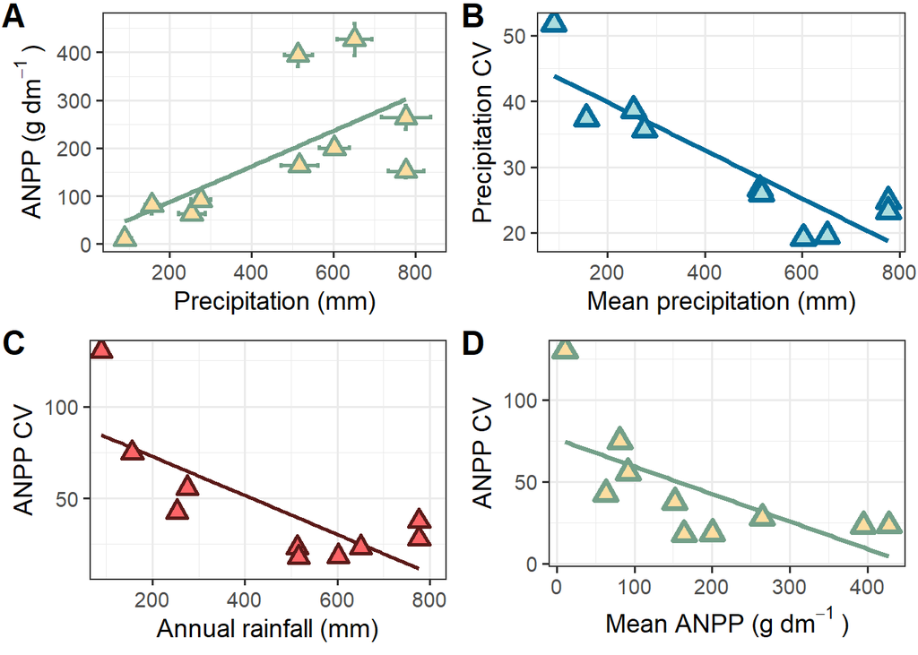

Data from 10 rangeland locations along an aridity gradient in Israel (Golodets et al. 2013 Climate Change)

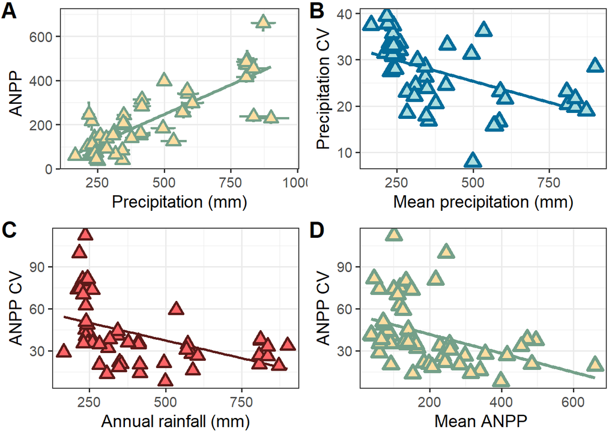

Data from 52 rangeland locations worldwide (Gherardi & Sala 2018 Global Change Biology)

In each case, pane C was presented in the paper, and the ecological interpretation was that variability in productivity increases with aridity—drier environments have greater fluctuations in annual primary productivity from year to year. The knock-on conclusion is often that ecosystems in these regions are therefore more sensitive:

> Climate change is more likely to affect herbaceous ANPP of rangelands in the arid end of the rainfall gradient, requiring adaptation of rangeland management, while ANPP of rangelands in more mesic ecosystems is less responsive to variation in rainfall. We conclude that herbaceous ANPP in most [mesic] rangelands is less vulnerable to climate change than generally predicted. (Golodets et al. 2013)

This interpretation overlooks the correlation inherent between $CV_{ANPP}$ and $\mu_{precip}$. Because $\mu_{ANPP}$ increases linearly with $\mu_{precip}$ (Pane A), $CV_{ANPP}$ will necessarily decline linearly with with $\mu_{precip}$ (Pane C), as well, due to the correlation between arithmetic processes (Panes B & D).

### Disturbance and standing crop

Precipitation gradients are not the only sources of variability in mean plant biomass. Disturbances such as grazing or fire can alter the standing crop—the amount of total productivity available to be measured.

**Grazing.$~~$**Changes in variability attributed to management can just as easily be explained by changes in the mean values used to calculate CV:

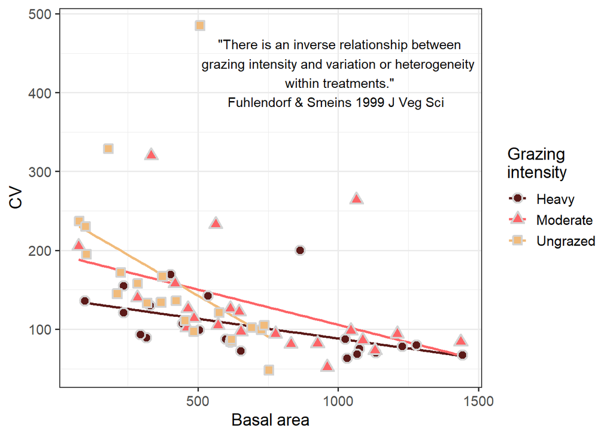

**Wildland fire.$~~$**Post-disturbance chronosequences—e.g., plant recovery of aboveground biomass following a fire—also conflate variability with the general increase in mean biomass over time:

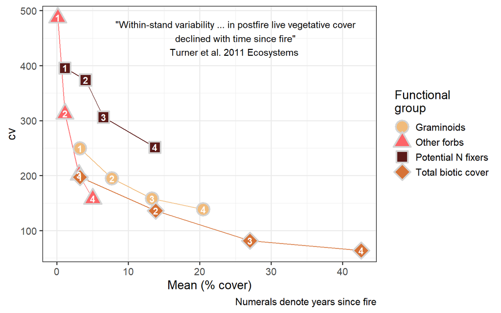

## Two unrelated variables

Perhaps even more convincing is the association between $CV_y$ and $x$ when there is no inherent, colinear relationship. In such cases it is easy to interpret changes in $x$ as the driver of stability in $y$. But as above, the $CV_y$ always declines linearly as $\mu_y$ increases, regardless (or even opposite) of the second variable $x$:

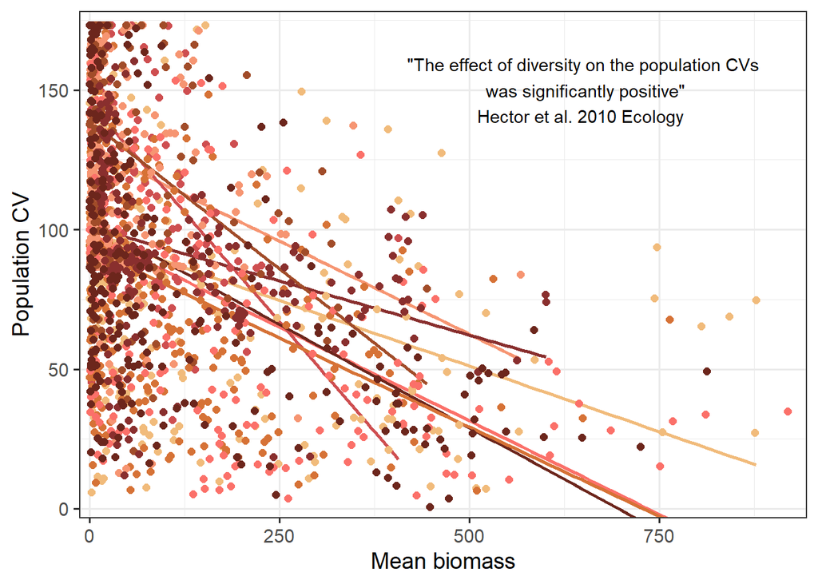

# Alternative perspective on variability

At least for some managers, variability might be conceptualized as how much they’d have to change up management to adapt to fluctuations in the environment. Using the global dataset compiled by Gherardi & Sala, the graph below shows how many animal units managers would need to find alternative grazing for were there to be a severe to extreme drought (5th percentile of productivity observed for each location). The scenario assumes stocking for 25% use of 100 ha for a 5-month grazing season.

On average, a rancher facing drought in a 250 mm rainfall zone would need to find alternative feed for 10 animal units for each 100 ha under management. Meanwhile, a rancher facing drought in a zone with 900 mm rainfall would need to find alternative feed for nearly 30 animal units for each 100 ha.

Is there an argument that the rancher in the higher rainfall zone is more affected by drought?

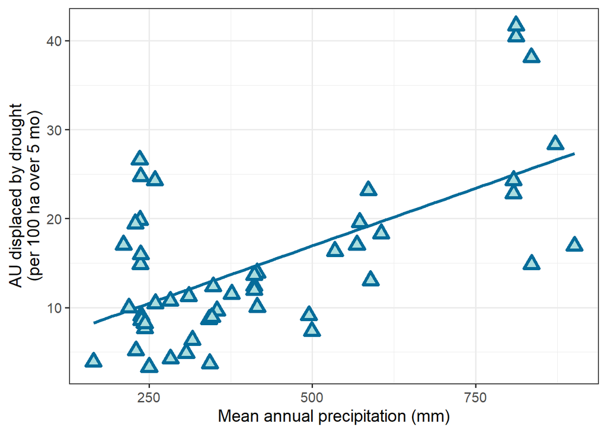